# Untitled-1

MRIDUL HARISH, CED18I034, END SEMESTER EXAMINATION

```python
conda install -c conda-forge/label/gcc7 missingno
```

```
Solving environment: ...working... done

# All requested packages already installed.
```

```python
pip install plotly
```

```python
import pandas as pd
import numpy as np
import matplotlib.pyplot as plt
import seaborn as sns
import missingno as msno
import plotly.express as px
import plotly.graph_objects as go


%matplotlib inline

import warnings
warnings.filterwarnings("ignore")
```

```python
main_df=pd.read_csv("dermatologyCSV.csv")
main_df.head()
```

|  | Index | erythema | scaling | definite borders | itching | koebner phenomenon | polygonal papules | follicular papules | oral mucosal involvement | knee and elbow involvement | ... | disappearance of the granular layer | vacuolisation and damage of basal layer | spongiosis | saw-tooth appearance of retes | follicular horn plug | perifollicular parakeratosis | inflammatory monoluclear inflitrate | band-like infiltrate | Age | Class |
| --- | --- | --- | --- | --- | --- | --- | --- | --- | --- | --- | --- | --- | --- | --- | --- | --- | --- | --- | --- | --- | --- |
| 0 | 1 | 2 | 2 | 0 | 3 | 0 | 0 | 0 | 0 | 1 | ... | 0 | 0 | 3 | 0 | 0 | 0 | 1 | 0 | 55.0 | 2 |
| 1 | 2 | 3 | 3 | 3 | 2 | 1 | 0 | 0 | 0 | 1 | ... | 0 | 0 | 0 | 0 | 0 | 0 | 1 | 0 | 8.0 | 1 |
| 2 | 3 | 2 | 1 | 2 | 3 | 1 | 3 | 0 | 3 | 0 | ... | 0 | 2 | 3 | 2 | 0 | 0 | 2 | 3 | 26.0 | 3 |
| 3 | 4 | 2 | 2 | 2 | 0 | 0 | 0 | 0 | 0 | 3 | ... | 3 | 0 | 0 | 0 | 0 | 0 | 3 | 0 | 40.0 | 1 |
| 4 | 5 | 2 | 3 | 2 | 2 | 2 | 2 | 0 | 2 | 0 | ... | 2 | 3 | 2 | 3 | 0 | 0 | 2 | 3 | 45.0 | 3 |

5 rows × 36 columns

```python
main_df.info()
```

```
<class 'pandas.core.frame.DataFrame'>
RangeIndex: 366 entries, 0 to 365
Data columns (total 36 columns):
 #   Column                                    Non-Null Count  Dtype
---  ------                                    --------------  -----
 0   Index                                     366 non-null    int64
 1   erythema                                  366 non-null    int64
 2   scaling                                   366 non-null    int64
 3   definite borders                          366 non-null    int64
 4   itching                                   366 non-null    int64
 5   koebner phenomenon                        366 non-null    int64
 6   polygonal papules                         366 non-null    int64
 7   follicular papules                        366 non-null    int64
 8   oral mucosal involvement                  366 non-null    int64
 9   knee and elbow involvement                366 non-null    int64
```

[output cut: 28 more lines]

CLEANING OF DATA

Finding the distribution of missing values in the data set

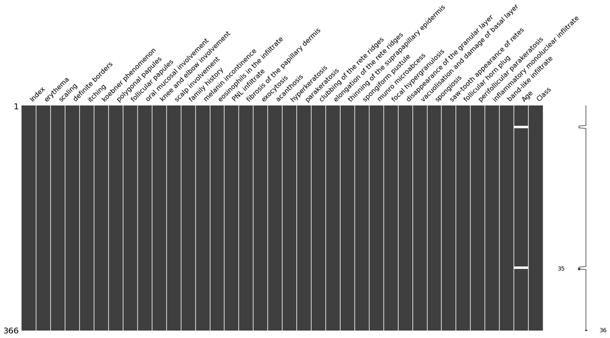

```python
msno.matrix(main_df);
```

Finding the number of data values in each coloumn and comparing them using a bar graph

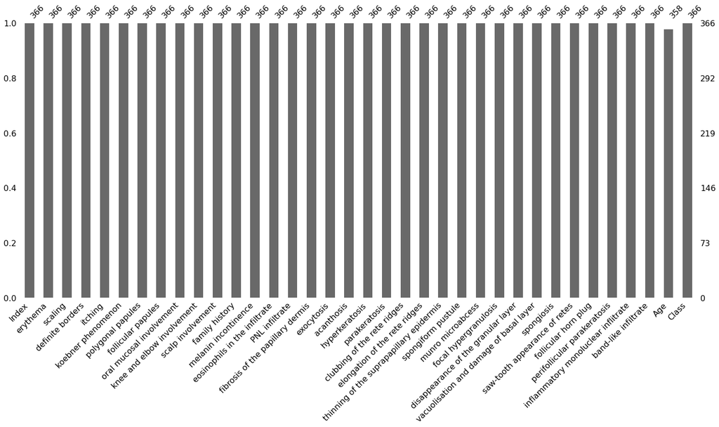

```python
msno.bar(main_df);
```

Finding the number of unique values for each attribute

```python
main_df.nunique()
```

```
Index                                       366
erythema                                      4
scaling                                       4
definite borders                              4
itching                                       4
koebner phenomenon                            4
polygonal papules                             4
follicular papules                            4
oral mucosal involvement                      4
knee and elbow involvement                    4
scalp involvement                             4
family history                                2
melanin incontinence                          4
eosinophils in the infiltrate                 3
PNL infiltrate                                4
fibrosis of the papillary dermis              4
exocytosis                                    4
acanthosis                                    4
hyperkeratosis                                4
parakeratosis                                 4
clubbing of the rete ridges                   4
elongation of the rete ridges                 4
thinning of the suprapapillary epidermis      4
spongiform pustule                            4
munro microabcess                             4
focal hypergranulosis                         4
disappearance of the granular layer           4
vacuolisation and damage of basal layer       4
spongiosis                                    4
saw-tooth appearance of retes                 4
follicular horn plug                          4
perifollicular parakeratosis                  4
inflammatory monoluclear inflitrate           4
band-like infiltrate                          4
Age                                          60
Class                                         6
dtype: int64
```

Finding out the number of missing values in each attribute

```python
main_df.isna().sum()
```

```
Index                                       0
erythema                                    0
scaling                                     0
definite borders                            0
itching                                     0
koebner phenomenon                          0
polygonal papules                           0
follicular papules                          0
oral mucosal involvement                    0
knee and elbow involvement                  0
scalp involvement                           0
family history                              0
melanin incontinence                        0
eosinophils in the infiltrate               0
PNL infiltrate                              0
fibrosis of the papillary dermis            0
exocytosis                                  0
acanthosis                                  0
hyperkeratosis                              0
parakeratosis                               0
clubbing of the rete ridges                 0
elongation of the rete ridges               0
thinning of the suprapapillary epidermis    0
spongiform pustule                          0
munro microabcess                           0
focal hypergranulosis                       0
disappearance of the granular layer         0
vacuolisation and damage of basal layer     0
spongiosis                                  0
saw-tooth appearance of retes               0
follicular horn plug                        0
perifollicular parakeratosis                0
inflammatory monoluclear inflitrate         0
band-like infiltrate                        0
Age                                         8
Class                                       0
dtype: int64
```

Filling up the missing values using the mean of that attribute

```python
main_df = pd.read_csv('dermatologyCSV.csv', na_values='?')

main_df.columns = ['index',
    'erythema',
    'scaling',
    'definite borders',
    'itching',
    'koebner phenomenon',
    'polygonal papules',
    'follicular papules',
    'oral mucosal involvement',
    'knee and elbow involvement',
    'scalp involvement',
    'family history',
    'melanin incontinence',
    'eosinophils in the infiltrate',
    'PNL infiltrate',
    'fibrosis of the papillary dermis',
    'exocytosis',
    'acanthosis',
    'hyperkeratosis',
    'parakeratosis',
    'clubbing of the rete ridges',
    'elongation of the rete ridges',
    'thinning of the suprapapillary epidermis',
    'spongiform pustule',
    'munro microabcess',
    'focal hypergranulosis',
    'disappearance of the granular layer',
    'vacuolisation and damage of basal layer',
    'spongiosis',
    'saw-tooth appearance of retes',
    'follicular horn plug',
    'perifollicular parakeratosis',
    'inflammatory monoluclear inflitrate',
    'band-like infiltrate',
    'Age',
    'Class'
]

main_df['Age'] = main_df['Age'].fillna(main_df['Age'].mean())
```

Verifying by rechecking the number of missing values in each attribute(it should be 0 for all)

```python
main_df.isna().sum()
```

```
index                                       0
erythema                                    0
scaling                                     0
definite borders                            0
itching                                     0
koebner phenomenon                          0
polygonal papules                           0
follicular papules                          0
oral mucosal involvement                    0
knee and elbow involvement                  0
scalp involvement                           0
family history                              0
melanin incontinence                        0
eosinophils in the infiltrate               0
PNL infiltrate                              0
fibrosis of the papillary dermis            0
exocytosis                                  0
acanthosis                                  0
hyperkeratosis                              0
parakeratosis                               0
clubbing of the rete ridges                 0
elongation of the rete ridges               0
thinning of the suprapapillary epidermis    0
spongiform pustule                          0
munro microabcess                           0
focal hypergranulosis                       0
disappearance of the granular layer         0
vacuolisation and damage of basal layer     0
spongiosis                                  0
saw-tooth appearance of retes               0
follicular horn plug                        0
perifollicular parakeratosis                0
inflammatory monoluclear inflitrate         0
band-like infiltrate                        0
Age                                         0
Class                                       0
dtype: int64
```

EXPLORATORY DATA ANALYTICS

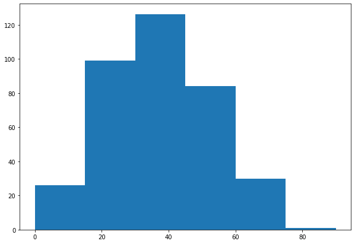

```python
fig, ax = plt.subplots(figsize =(10, 7))
ax.hist(main_df.Age, bins = [0, 15, 30, 45, 60, 75, 90])
```

```python
AgeP = main_df.Age
AgeP%10
```

```
0      5.0
1      8.0
2      6.0
3      0.0
4      5.0
      ...
361    5.0
362    6.0
363    8.0
364    0.0
365    5.0
Name: Age, Length: 366, dtype: float64
```

```
<StemContainer object of 3 artists>
```

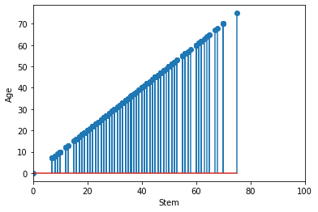

```python
plt.ylabel('Age')
plt.xlabel('Stem')
plt.xlim(0, 100)
plt.stem(AgeP, main_df.Age)
```

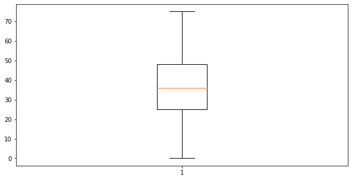

```python
fig = plt.figure(figsize=(10, 5))
plt.boxplot(AgeP)
plt.show()
```

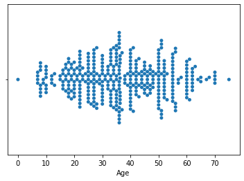

```python
sns.swarmplot(x=AgeP)
```

ACLOSE ALGORITHM

There are many different approaches trying to efficiently find close and maximal frequent itemsets.

Importing all the basic librarys

Computing the Frequent Item Set using mlxtend.frequent_patterns

```python
from mlxtend.preprocessing import TransactionEncoder
import time
from mlxtend.frequent_patterns import fpgrowth
```

```python
te = TransactionEncoder()
te_ary = te.fit('dermatologyCSV.csv').transform('dermatologyCSV.csv')
df = pd.DataFrame(te_ary, columns=te.columns_)
```

```python
start_time = time.time()
frequent = fpgrowth(df, min_support=0.001, use_colnames=True)
print('Time to find frequent itemset')
print("--- %s seconds ---" % (time.time() - start_time))
```

```
Time to find frequent itemset
--- 0.20922088623046875 seconds ---
```

Finding closed/max frequent itemset using frequent itemset found in task1

```python
su = frequent.support.unique()
```

Dictionary storing the itemset with same support count key

```python
fredic = {}
for i in range(len(su)):
    inset = list(frequent.loc[frequent.support ==su[i]]['itemsets'])
    fredic[su[i]] = inset
```

Dictionary storing the itemset with support count <= key

```python
fredic2 = {}
for i in range(len(su)):
    inset2 = list(frequent.loc[frequent.support<=su[i]]['itemsets'])
    fredic2[su[i]] = inset2
```

Finding Closed frequent itemset

```python
start_time = time.time()
```

```python
cl = []
for index, row in frequent.iterrows():
    isclose = True
    cli = row['itemsets']
    cls = row['support']
    checkset = fredic[cls]
    for i in checkset:
        if (cli!=i):
            if(frozenset.issubset(cli,i)):
                isclose = False
                break

    if(isclose):
        cl.append(row['itemsets'])

print('Time to find Close frequent itemset')
print("--- %s seconds ---" % (time.time() - start_time))
```

```
Time to find Close frequent itemset
--- 111.80388355255127 seconds ---
```

```python
cl
```

```
[frozenset({'d'}),
 frozenset({'e'}),
 frozenset({'r'}),
 frozenset({'m'}),
 frozenset({'a'}),
 frozenset({'t'}),
 frozenset({'o'}),
 frozenset({'l'}),
 frozenset({'g'}),
 frozenset({'y'}),
 frozenset({'C'}),
 frozenset({'S'}),
 frozenset({'V'}),
 frozenset({'.'}),
 frozenset({'c'}),
 frozenset({'s'}),
 frozenset({'v'})]
```

Finding Maximal frequent itemset

```python
start_time = time.time()
```

```python
ml = []
for index, row in frequent.iterrows():
    isclose = True
    cli = row['itemsets']
    cls = row['support']
    checkset = fredic2[cls]
    for i in checkset:
        if (cli!=i):
            if(frozenset.issubset(cli,i)):
                isclose = False
                break
    if(isclose):
        ml.append(row['itemsets'])
```

```python
print('Time to find Max frequent itemset')
print("--- %s seconds ---" % (time.time() - start_time))
```

```
Time to find Max frequent itemset
--- 124.77249717712402 seconds ---
```

```python
ml
```

```
[frozenset({'d'}),
 frozenset({'e'}),
 frozenset({'r'}),
 frozenset({'m'}),
 frozenset({'a'}),
 frozenset({'t'}),
 frozenset({'o'}),
 frozenset({'l'}),
 frozenset({'g'}),
 frozenset({'y'}),
 frozenset({'C'}),
 frozenset({'S'}),
 frozenset({'V'}),
 frozenset({'.'}),
 frozenset({'c'}),
 frozenset({'s'}),
 frozenset({'v'})]
```

KNN CLASSIFICATION/REGRESSION

The intuition behind the KNN algorithm is one of the simplest of all the supervised machine learning algorithms. It simply calculates the distance of a new data point to all other training data points. The distance can be of any type e.g Euclidean or Manhattan etc. It then selects the K-nearest data points, where K can be any integer. Finally it assigns the data point to the class to which the majority of the K data points belong.

In this section we'll present some of the pros and cons of using the KNN algorithm. Pros

[output not shown]

Cons

```
The KNN algorithm doesn't work well with high dimensional data because with large number of dimensions, it becomes difficult for the algorithm to calculate distance in each dimension.
The KNN algorithm has a high prediction cost for large datasets. This is because in large datasets the cost of calculating distance between new point and each existing point becomes higher.
Finally, the KNN algorithm doesn't work well with categorical features since it is difficult to find the distance between dimensions with categorical features.
```

Splitting our dataset into its attributes and labels.

```python
X = main_df.iloc[:, :-1].values
Y = main_df.iloc[:, 35].values
```

```python
X
```

[output not shown]

```python
Y
```

```
array([2, 1, 3, 1, 3, 2, 5, 3, 4, 4, 1, 2, 2, 1, 3, 4, 2, 1, 3, 5, 6, 2,
       5, 3, 5, 1, 6, 5, 2, 3, 1, 2, 1, 1, 4, 2, 3, 2, 3, 1, 2, 4, 1, 2,
       5, 3, 4, 6, 2, 3, 3, 4, 1, 1, 5, 1, 2, 3, 4, 2, 6, 1, 5, 1, 2, 3,
       1, 4, 5, 1, 2, 6, 3, 5, 4, 2, 2, 1, 3, 5, 1, 2, 2, 2, 5, 1, 1, 3,
       1, 4, 2, 2, 5, 1, 3, 4, 2, 5, 1, 6, 2, 5, 1, 2, 2, 1, 4, 1, 3, 1,
       1, 3, 5, 3, 3, 5, 2, 3, 4, 1, 2, 5, 6, 1, 1, 2, 6, 3, 5, 4, 1, 1,
       3, 5, 5, 1, 4, 2, 3, 1, 2, 1, 1, 3, 3, 3, 2, 5, 4, 2, 2, 1, 1, 1,
       5, 3, 2, 3, 2, 2, 4, 2, 3, 6, 2, 1, 1, 3, 4, 3, 3, 1, 1, 1, 3, 1,
       1, 2, 3, 3, 1, 1, 1, 1, 6, 2, 2, 2, 2, 1, 3, 3, 3, 1, 1, 2, 3, 2,
       2, 2, 5, 5, 5, 5, 5, 1, 1, 1, 1, 1, 1, 1, 3, 3, 3, 3, 3, 3, 4, 4,
       4, 4, 5, 5, 5, 5, 5, 5, 5, 2, 2, 2, 2, 1, 1, 1, 1, 1, 1, 6, 6, 1,
       1, 1, 1, 1, 1, 1, 1, 3, 3, 3, 3, 3, 3, 3, 4, 4, 4, 4, 4, 4, 5, 5,
       5, 5, 6, 6, 6, 4, 4, 4, 1, 1, 1, 1, 1, 2, 2, 4, 4, 4, 1, 1, 2, 2,
       2, 3, 3, 3, 3, 1, 1, 1, 1, 5, 5, 5, 5, 5, 3, 3, 3, 4, 1, 1, 4, 4,
       4, 1, 1, 1, 3, 3, 3, 3, 3, 1, 1, 1, 1, 4, 4, 1, 1, 4, 3, 3, 4, 1,
       1, 4, 4, 5, 5, 1, 1, 5, 5, 3, 1, 5, 5, 6, 6, 4, 4, 6, 6, 6, 1, 1,
       1, 5, 5, 1, 1, 1, 1, 2, 2, 4, 4, 3, 3, 1], dtype=int64)
```

To avoid over-fitting, we will divide our dataset into training and test splits, which gives us a better idea as to how our algorithm performed during the testing phase. This way our algorithm is tested on un-seen data, as it would be in a production application.

The below script splits the dataset into 80% train data and 20% test data.

```python
from sklearn.model_selection import train_test_split
X_train, X_test, Y_train, Y_test = train_test_split(X, Y, test_size=0.20)
```

Before making any actual predictions, it is always a good practice to scale the features so that all of them can be uniformly evaluated.

Since the range of values of raw data varies widely, in some machine learning algorithms, objective functions will not work properly without normalization. For example, the majority of classifiers calculate the distance between two points by the Euclidean distance. If one of the features has a broad range of values, the distance will be governed by this particular feature. Therefore, the range of all features should be normalized so that each feature contributes approximately proportionately to the final distance.

```python
from sklearn.preprocessing import StandardScaler
scaler = StandardScaler()
scaler.fit(X_train)

X_train = scaler.transform(X_train)
X_test = scaler.transform(X_test)
```

The first step is to import the KNeighborsClassifier class from the sklearn.neighbors library. In the second line, this class is initialized with one parameter, i.e. n_neigbours. This is basically the value for the K.

```python
from sklearn.neighbors import KNeighborsClassifier
classifier = KNeighborsClassifier(n_neighbors=5)
classifier.fit(X_train, Y_train)
```

```
KNeighborsClassifier()
```

```python
Y_pred = classifier.predict(X_test)
```

For evaluating an algorithm, confusion matrix, precision, recall and f1 score are the most commonly used metrics. The confusion_matrix and classification_report methods of the sklearn.metrics can be used to calculate these metrics.

```python
from sklearn.metrics import classification_report, confusion_matrix
print(confusion_matrix(Y_test, Y_pred))
print(classification_report(Y_test, Y_pred))
```

```
[[17  0  0  0  0  0]
 [ 0 15  0  4  0  0]
 [ 0  0 13  0  0  0]
 [ 0  0  0 11  0  0]
 [ 0  0  0  0  8  0]
 [ 0  0  0  0  0  6]]
              precision    recall  f1-score   support

           1       1.00      1.00      1.00        17
           2       1.00      0.79      0.88        19
           3       1.00      1.00      1.00        13
           4       0.73      1.00      0.85        11
           5       1.00      1.00      1.00         8
           6       1.00      1.00      1.00         6

    accuracy                           0.95        74
   macro avg       0.96      0.96      0.95        74
weighted avg       0.96      0.95      0.95        74
```

One way to help you find the best value of K is to plot the graph of K value and the corresponding error rate for the dataset.

In this section, we will plot the mean error for the predicted values of test set for all the K values between 1 and 40.

To do so, let's first calculate the mean of error for all the predicted values where K ranges from 1 and 40.

```python
error = []

for i in range(1, 40):
    knn = KNeighborsClassifier(n_neighbors=i)
    knn.fit(X_train, Y_train)
    pred_i = knn.predict(X_test)
    error.append(np.mean(pred_i != Y_test))
```

In each iteration the mean error for predicted values of test set is calculated and the result is appended to the error list

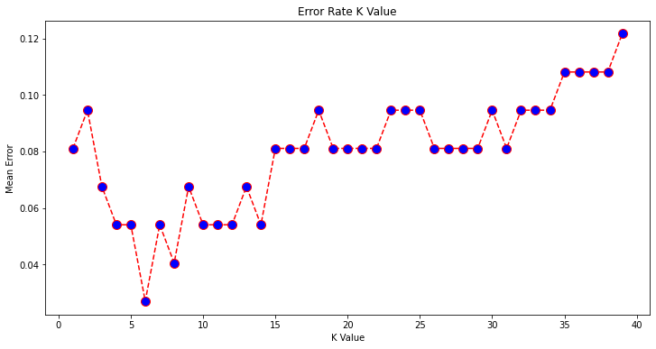

```python
plt.figure(figsize=(12, 6))
plt.plot(range(1, 40), error, color='red', linestyle='dashed', marker='o',
         markerfacecolor='blue', markersize=10)
plt.title('Error Rate K Value')
plt.xlabel('K Value')
plt.ylabel('Mean Error')
```

AGNES Clustering

Steps to Perform AGNES Clustering

Following are the steps involved in agglomerative clustering:

```
At the start, treat each data point as one cluster. Therefore, the number of clusters at the start will be K, while K is an integer representing the number of data points.
Form a cluster by joining the two closest data points resulting in K-1 clusters.
Form more clusters by joining the two closest clusters resulting in K-2 clusters.
Repeat the above three steps until one big cluster is formed.
Once single cluster is formed, dendrograms are used to divide into multiple clusters depending upon the problem. We will study the concept of dendrogram in detail in an upcoming section.
```

There are different ways to find distance between the clusters. The distance itself can be Euclidean or Manhattan distance. Following are some of the options to measure distance between two clusters:

```
Measure the distance between the closes points of two clusters.
Measure the distance between the farthest points of two clusters.
Measure the distance between the centroids of two clusters.
Measure the distance between all possible combination of points between the two clusters and take the mean.
```

```python
AgePlot = main_df.Age
IndexPlot = main_df.index
```

Plotting the scatter plot of the Age attribute

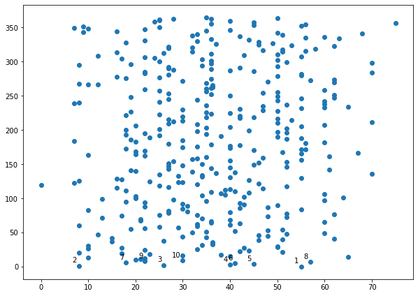

```python
import matplotlib.pyplot as plt

labels = range(1, 11)
plt.figure(figsize=(10, 7))
plt.subplots_adjust(bottom=0.1)
plt.scatter(AgePlot, IndexPlot , label='True Position')

for label, x, y in zip(labels, AgePlot, IndexPlot):
    plt.annotate(
        label,
        xy=(x, y), xytext=(-3, 3),
        textcoords='offset points', ha='right', va='bottom')
plt.show()
```

```python
X = []

for i in range(0, 366):
    X.append([AgePlot[i], IndexPlot[i]])
```

```python
X
```

```
[[55.0, 0],
 [8.0, 1],
 [26.0, 2],
 [40.0, 3],
 [45.0, 4],
 [41.0, 5],
 [18.0, 6],
 [57.0, 7],
 [22.0, 8],
 [30.0, 9],
 [20.0, 10],
 [21.0, 11],
 [22.0, 12],
 [10.0, 13],
 [65.0, 14],
 [40.0, 15],
 [30.0, 16],
 [38.0, 17],
 [23.0, 18],
 [17.0, 19],
 [8.0, 20],
 [51.0, 21],
 [42.0, 22],
 [44.0, 23],
 [22.0, 24],
 [33.0, 25],
 [10.0, 26],
 [17.0, 27],
 [43.0, 28],
 [50.0, 29],
 [50.0, 30],
 [10.0, 31],
 [34.0, 32],
 [36.29608938547486, 33],
 [36.29608938547486, 34],
 [36.29608938547486, 35],
 [36.29608938547486, 36],
 [15.0, 37],
 [26.0, 38],
 [46.0, 39],
```

[output cut: 311 more lines]

```
 [9.0, 351],
 [55.0, 352],
 [45.0, 353],
 [56.0, 354],
 [36.0, 355],
 [75.0, 356],
 [45.0, 357],
 [24.0, 358],
 [40.0, 359],
 [25.0, 360],
 [25.0, 361],
 [36.0, 362],
 [28.0, 363],
 [50.0, 364],
 [35.0, 365]]
```

Forming a Dendogram

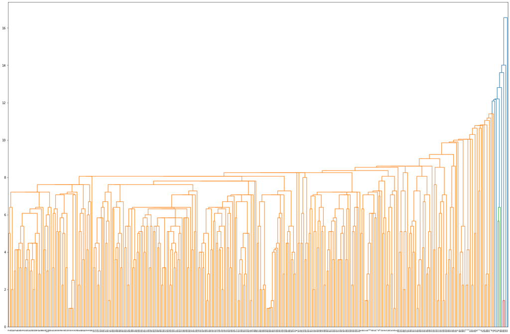

```python
from scipy.cluster.hierarchy import dendrogram, linkage
from matplotlib import pyplot as plt

linked = linkage(X, 'single')

labelList = range(0, 366)

plt.figure(figsize=(30, 20))
dendrogram(linked,
            orientation='top',
            labels=labelList,
            distance_sort='descending',
            show_leaf_counts=True)
plt.show()
```

```
Number of clusters = 8
Classifying the points into clusters:
[0 0 0 0 0 0 0 0 0 0 0 0 0 0 0 0 0 0 0 0 0 0 0 0 0 0 0 0 0 0 0 0 0 0 0 0 0
 0 0 0 0 0 0 0 0 0 0 0 0 0 0 0 0 0 0 0 0 0 0 0 0 0 0 0 0 7 0 7 0 7 7 7 7 7
 7 7 7 7 7 7 7 7 7 7 7 7 7 7 7 7 7 7 7 7 7 7 7 2 7 7 7 2 2 7 2 2 2 2 2 2 2
 2 2 2 2 2 2 2 2 2 2 2 2 2 2 2 2 2 2 2 2 2 4 2 4 2 4 4 4 4 2 2 4 4 4 4 4 4
 4 4 4 4 4 4 4 4 4 4 4 4 4 4 4 4 4 4 4 4 4 4 4 4 4 4 4 4 4 4 4 4 4 4 4 6 6
 4 6 4 4 6 4 6 6 6 6 6 6 6 6 6 6 6 6 6 6 6 6 6 6 6 6 6 6 6 6 6 6 6 6 3 3 6
 3 3 3 3 3 3 3 3 3 3 3 3 3 3 3 3 3 3 3 3 3 3 3 3 3 3 3 3 3 3 3 3 3 3 3 3 3
 3 5 5 5 5 5 5 5 5 5 5 5 5 5 5 5 5 5 5 5 5 5 5 5 5 5 5 5 5 5 5 5 5 5 5 5 1
 1 5 5 5 1 5 5 5 1 1 1 1 1 1 1 1 1 1 1 1 1 1 1 1 1 1 1 1 1 1 1 1 1 1 1 1 1
 1 1 1 1 1 1 1 1 1 1 1 1 1 1 1 1 1 1 1 1 1 1 1 1 1 1 1 1 1 1 1 1 1]
```

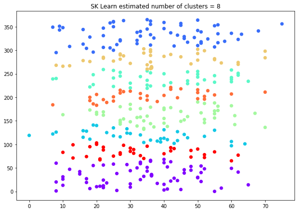

```python
cluster = AgglomerativeClustering(n_clusters=None, affinity='euclidean', linkage='ward', compute_full_tree=True, distance_threshold=200)

cluster.fit_predict(X)

print(f"Number of clusters = {1+np.amax(cluster.labels_)}")

print("Classifying the points into clusters:")
print(cluster.labels_)

plt.figure(figsize=(10, 7))
plt.scatter(AgePlot ,IndexPlot, c=cluster.labels_, cmap='rainbow')
plt.title(f"SK Learn estimated number of clusters = {1+np.amax(cluster.labels_)}")
plt.show()
```

Plot of the clusters